# Final Paper

STOR 320.01 Group 5

October 22, 2021

# INTRODUCTION

In order to maximize entertainment and minimize costs, it is important for consumers to choose the right streaming service that not only shows the highest quality films, but the films they are most interested in. This analysis aims to further understand how streaming services, IMDb score, and Rotten Tomatoes ratings are all interconnected and how these connections can allow for more strategic purchases on the consumer end and more intuitive sales on the content creation end. For the purpose of exploring these connections, the following tables and models attempt to answer two critical questions: What are the most influential factors that IMDb uses to determine their ratings of films? And how do these compare with the characteristics used by Rotten Tomatoes?

We were then able to investigate several characteristics and their relation to critical ratings and streaming service. The characteristics were year of release, target age demographic, director, country, languages the content is available in, and genre. The reason we chose to investigate several factors was to find the one characteristic that affects IMDb and Rotten Tomato scores the most. This way, the private sector could use this information to curate a film selection with the maximum appeal, and consumers could use this information to determine if specific streaming services stream lower or higher quality content.

Understanding the way IMDb and Rotten Tomatoes, two of the most widely accepted and sought out critical reviewing groups, creates their rating system allows the user to align their spending habits and interests by deciding which streaming services best suit their needs.

# DATA

Our selected data set was web scraped in 2020 by Ruchi Bhatia, a data scientist from Mumbai, India. She created the data set with the intention of determining which platforms movies can be found on, as well as the average ratings for movies based on the country of production. It contains 16,774 unique movies that are included with a subscription to Netflix, Hulu, Prime Video, or Disney+. These specific platforms are currently the four most subscribed to streaming services in the US. The table below gives a look into the format of the data set we worked with.

| Title | Year | Age | IMDb | Rotten Tomatoes | Netflix | Hulu | Prime Video | Disney+ | Directors | Genres | Country | Language |
| --- | --- | --- | --- | --- | --- | --- | --- | --- | --- | --- | --- | --- |
| Inception | 2010 | 13+ | 8.8 | 87% | 1 | 0 | 0 | 0 | Christopher Nolan | Action,Adventure,Sci-Fi,Thriller | United States,United Kingdom | English,Japanese,French |
| The Matrix | 1999 | 18+ | 8.7 | 87% | 1 | 0 | 0 | 0 | Lana Wachowski,Lilly Wachowski | Action,Sci-Fi | United States | English |
| Avengers: Infinity War | 2018 | 13+ | 8.5 | 84% | 1 | 0 | 0 | 0 | Anthony Russo,Joe Russo | Action,Adventure,Sci-Fi | United States | English |
| Back to the Future | 1985 | 7+ | 8.5 | 96% | 1 | 0 | 0 | 0 | Robert Zemeckis | Adventure,Comedy,Sci-Fi | United States | English |
| The Good, the Bad and the Ugly | 1966 | 18+ | 8.8 | 97% | 1 | 0 | 1 | 0 | Sergio Leone | Western | Italy,Spain,West Germany | Italian |

For each movie title, the data set indicates the platform(s) it is on, as well as the average audience ratings from both IMDb and Rotten Tomatoes. The streaming service that offers the movie is designated by a 1 in the respective column, otherwise a 0 will be present. The IMDb ratings are on a scale from 0 to 10 and rounded to the nearest tenth, while the Rotten Tomatoes score is a percentage rounded to the nearest integer. The data set also contains several other characteristics of each movie. Year is a numeric variable that indicates the year each movie was produced, not when it was added to the streaming service. Age is a categorical variable showing recommended minimum age to watch the movie based off the Movie Picture Association film rating system. This is the same system that categorizes films into the widely accepted categories of G, PG, PG-13, and R. The options for age are all, 7+, 13+, and 18+ in alignment with these ratings. The Directors variable lists the director(s) credited with the film, each separated by a comma in the case of multiple directors. Similarly, the Genres variable indicates the genre(s) of the movie, once again separated by a comma. The same goes for Country and Language, which list the countries and languages that the movies are available in.

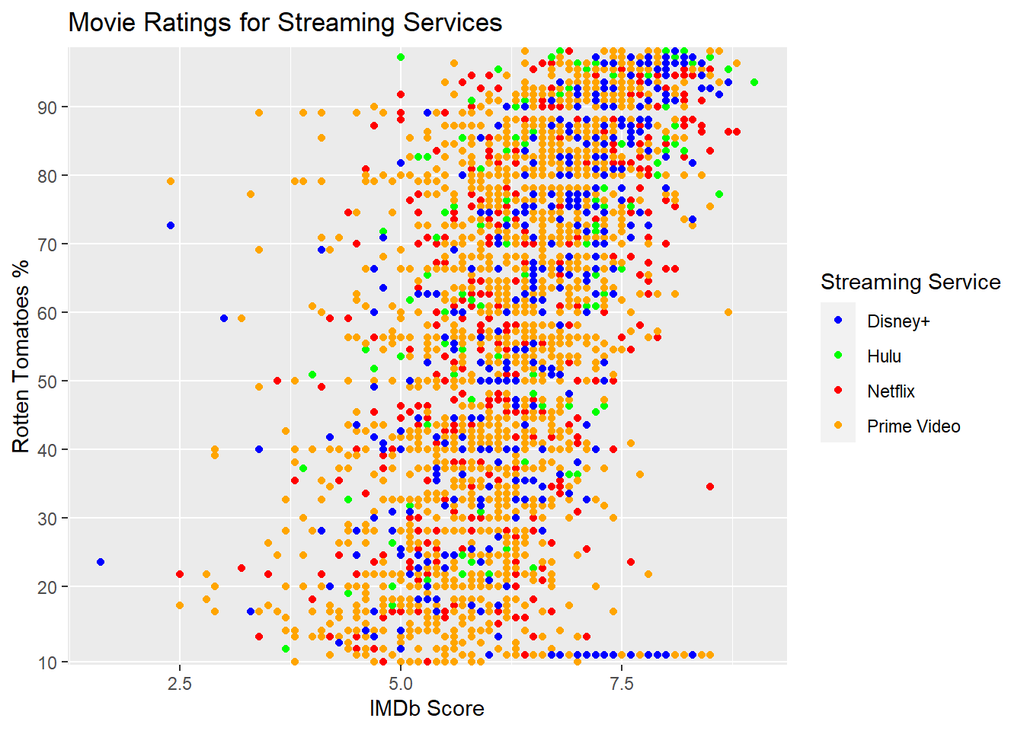

By visualizing the IMDb and Rotten Tomatoes ratings against each other in this manner, we can see that these groups rate films in a similar way, but these rating systems are not the same. In order to find out which rating we as the consumer trust more, we need to understand the factors that lend to these rankings. Further, grouping these points by streaming service shows that no streaming service is has an objectively better movie selection, and it is therefore up to the consumer to place themselves within these rating systems and decide for themselves what they care about and which streaming service is best catered to their needs.

# RESULTS

In finding the best prediction models, we wanted to use two modelling functions with opposing potential biases paired with cross validation to ensure we found coefficient approximations with the highest accuracy but without over-fitting the data. Due to this, the two tests we used to find the best model for predicting IMDb and Rotten Tomatoes ratings was Random Forest Regression and Lasso Regression. Random Forest Regression allowed us to aggregate many decision models based off the predictor variables and run them in parallel to produce a mean regression prediction. This form of regression was helpful to our analysis because the function pulls randomly from the data set to find the model with the lowest error, and tests the strength of all potentially predictive features over the outcome. We also utilized Lasso Regression to find the best fit model for predicting critical ratings because of the multicollinearity of the data, and because Lasso Regression balances the bias towards over-fitting in Random Forest Regression. Using Lasso Regression to test the strength of each predictor variable and using both the Lasso Approximations and Random Forest Approximations for each coefficient eliminated the biases of both modelling functions to find the most accurate predictions for each rating system.

### Prediction of IMDb Rating

#### Random Forest Regression

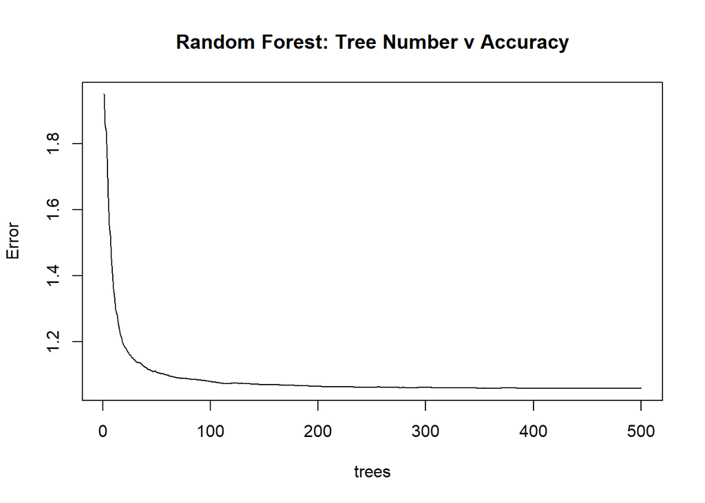

The graph above illustrates the error of predictions graphed against the number of trees used in generating that prediction. Random Forest Regression aims to find the most accurate model of prediction by generating and comparing a multitude of decision trees. The more trees added to the model, the more accurate it will be but the more overly complicated and over-fit it can become. The number of trees used in our prediction was generated to be close to the horizontal asymptote of this graph, such that the prediction was as accurate as possible but not overly complicated.

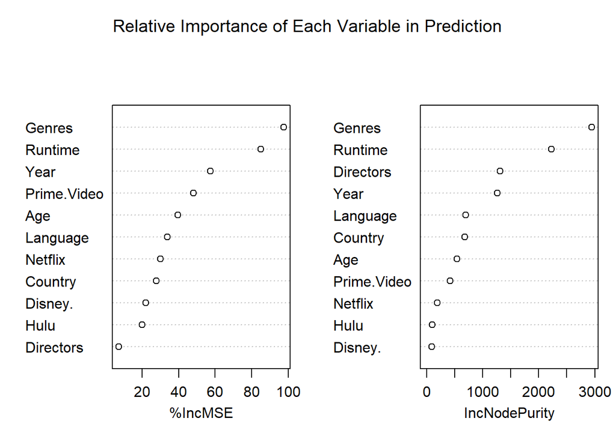

The plot above illustrates the relative importance of each variable, which was used in the determination of coefficients to provide the most accurate model. Focusing on the percentage increased in mean squared error, it’s clear to see that ‘Genres’ has the highest variable importance, followed by ‘Runtime’ and ‘Year’, resulting in higher predictive power in the analysis. Removing these variables of high importance generates significant loss of accuracy on the prediction results. On the other hand, looking at the table of increased node purity, we see some differences compared to percentage increase in mean square error, which is one of the results of measuring the node impurity. Splits of the dataset based on each variable is biased towards variables with many classes, which also biases the importance measure. In our case, the bias results in different orders regarding the importance of variables. However, ‘Genres’ and ‘Runtime’ have the highest importance in both ways.

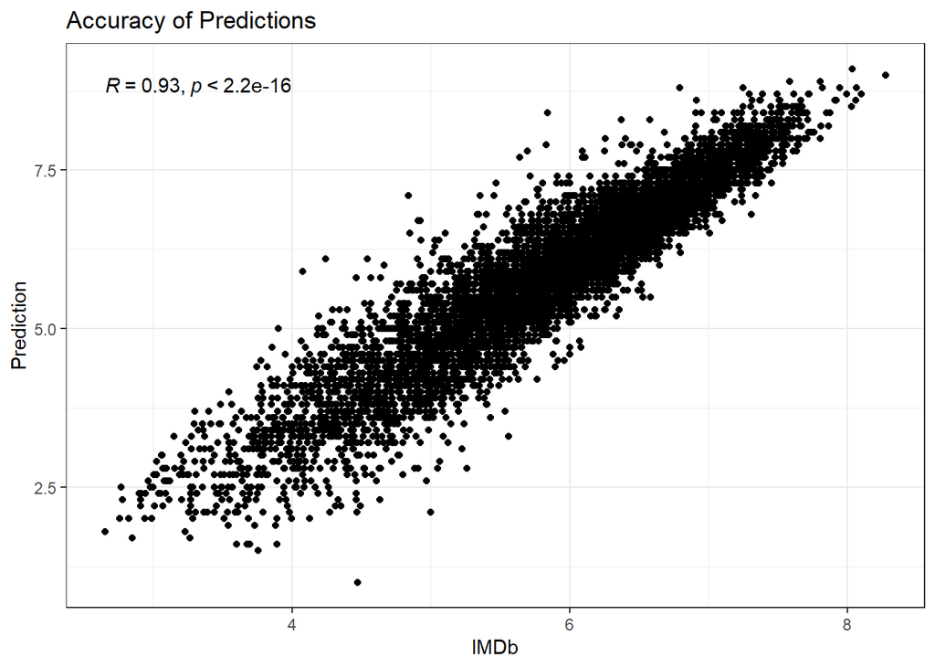

The figure above illustrates the accuracy of the Random Forest Predictions against the actual IMDb ratings for each title, as well as the R and p-values of the model. The shape of the points shows a positive correlation between the prediction and observed IMDb rating, roughly resembling a straight line which indicates a highly accurate model. This is reflected in the R value, the p-value, and the Root Mean Squared Error. These results indicate that the relative importance of each coefficient measured by Random Forest Regression is an accurate prediction of how IMDb is measured.

| Root Mean Squared Error |
| --- |
| 0.5801224 |

The Root Mean Squared Error indicates that Random Forest is a very accurate tool to test the relative importance of each coefficient in predicting IMDb score. The coefficients listed in order of importance by this model are `Genre`, `Runtime`, `Year`, `Prime.Video`, `Age`, `Language`, `Netflix`, `Country`, `Disney`, `Hulu`, and `Directors`.

#### Lasso Regression

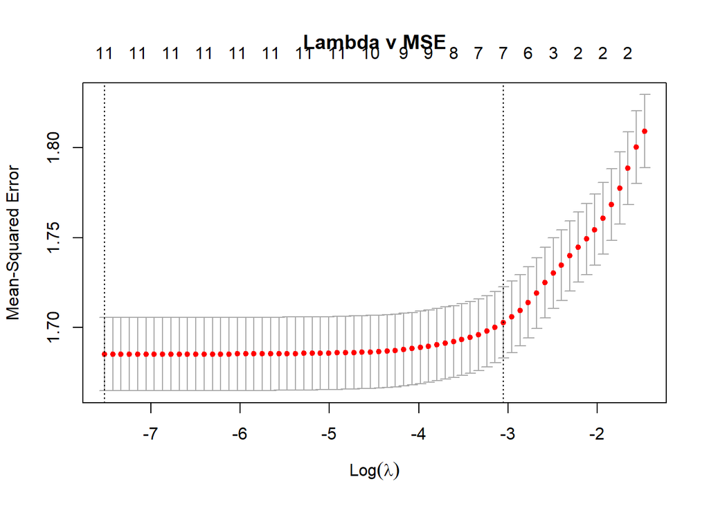

The plot above shows, with error margins, the Mean Squared Error of each Regression model against the Lambda used in creating that prediction. The goal of Lasso Regression is to find and use the Lambda value that minimizes error without making the model over-fit to the data. The best lambda calculated by the model and used in our analysis is the one which minimizes error, which appears to be along the horizontal anymptote.

| Variable | Coefficients |
| --- | --- |
| Intercept | 17.2152650 |
| Year | -0.0059309 |
| Age | -0.0162842 |
| Netflix | 0.3306114 |
| Hulu | 0.2693968 |
| Amazon Prime Video | -0.2146358 |
| Disney + | 0.6558939 |
| Directors | 0.0000045 |
| Genres | 0.0003411 |
| Country | -0.0000940 |
| Language | 0.0007147 |
| Run Time | 0.0024544 |

|  | Test Set | Train Set |
| --- | --- | --- |
| RMSE | 1.2968174 | 1.3372170 |
| R square | 0.0705185 | 0.0204115 |

In the calculation of Root Mean Squared Error and R-squared values, it is worth noting that the R-squared value for both the training set and the testing set is close to 0. This means that Lasso Regression was able to quantify the relationship between each variable and the IMDb rating, but these coefficients were not able to accurately predict IMDb ratings, and that the relative importance calculated by the Random Forest Regression may be more appropriate for comparison.

### Prediction of Rotten Tomatoes Ranking

#### Random Forest Regression

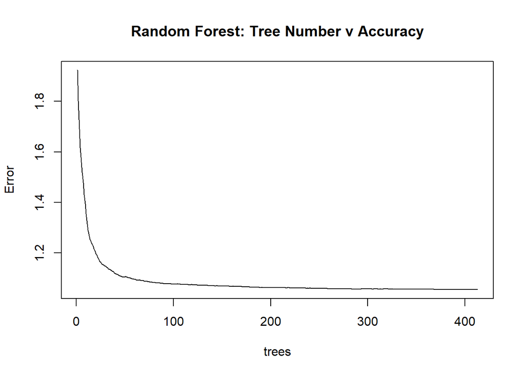

The graph above illustrates the error of predictions graphed against the number of trees used in generating that prediction. The number of trees used in our prediction was generated to be close to the horizontal asymptote of this graph, such that the prediction was as accurate as possible but not overly complicated. The shape of this graph is the same as the graph of tree number v accuracy in the random forest regression to predict IMDb score, indicating that predicting Rotten Tomatoes is not more or less complicated. This makes sense from our data because both models use the same variables.

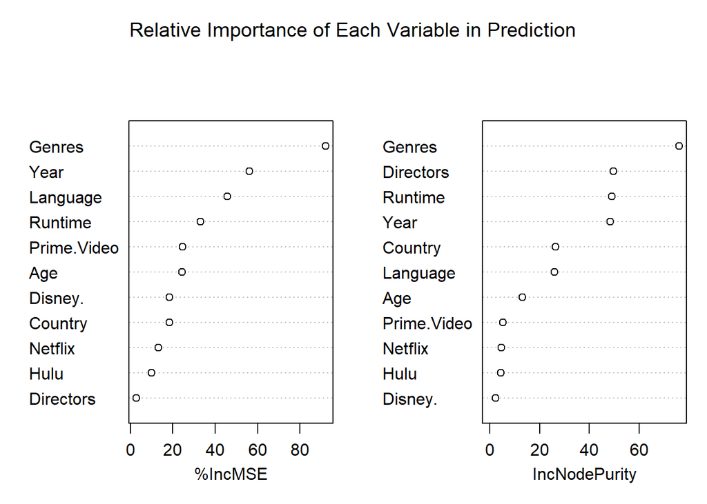

The plot above illustrates the relative importance of each variable, which was used in the determination of coefficients to provide the most accurate model. As the same as before when predicting IMDb ratings, there are differences in orders regarding the importance of each variables between the two methods we see above. Nevertheless, the results illustrate that ‘Genres’ has the highest importance of all variables in both figures, which means it has the highest predictive power and is the most decisive factor in the future prediction analysis.

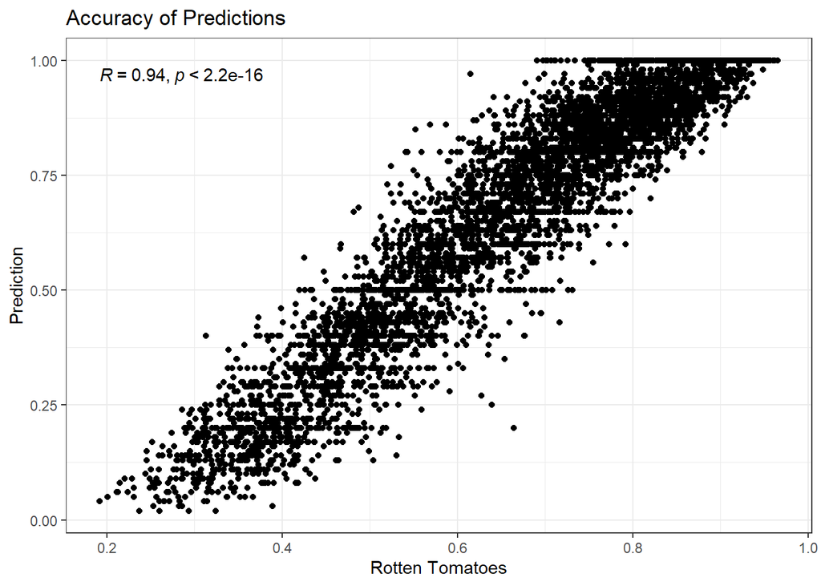

| Root Mean Squared Error |
| --- |
| 0.1223272 |

The Root Mean Squared Error indicates that Random Forest is a very accurate tool to test the relative importance of each coefficient in predicting Rotten Tomatoes score. The coefficients listed in order of importance by this model are `Genre`, `Year`, `Language`, `Runtime`, `Prime.Video`, `Age`, `Country`, `Disney.`, `Netflix`, `Hulu`, and `Directors`.

#### Lasso Regression

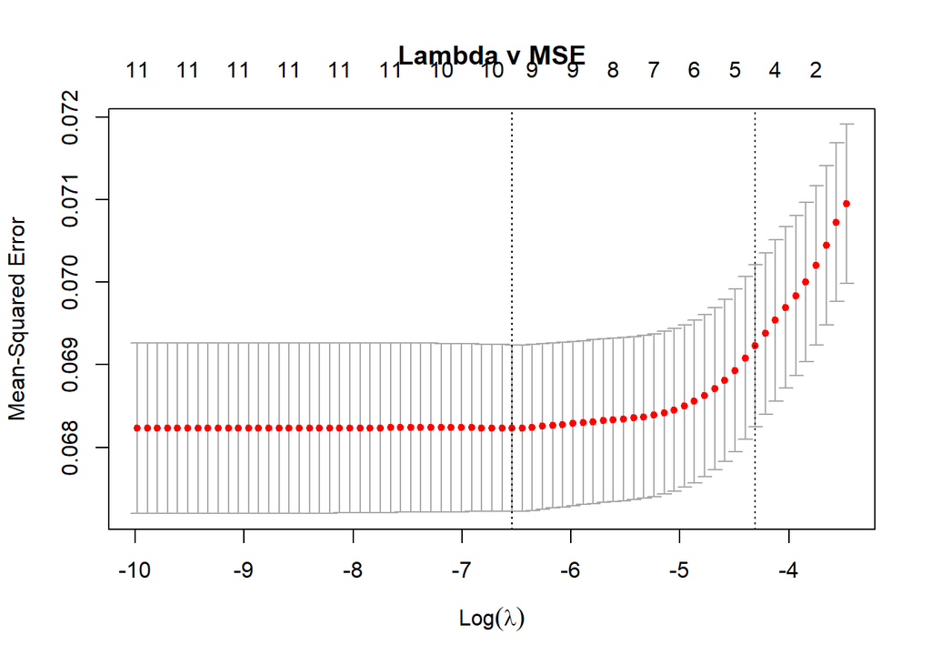

| Variable | Coefficients |
| --- | --- |
| Intercept | 3.0171573 |
| Year | -0.0012104 |
| Age | 0.0145828 |
| Netflix | -0.0171518 |
| Hulu | 0.0000000 |
| Amazon Prime Video | -0.0525081 |
| Disney + | -0.0346291 |
| Directors | 0.0000000 |
| Genres | 0.0001450 |
| Country | -0.0000438 |
| Language | 0.0002422 |
| Run Time | -0.0002818 |

|  | Test Set | Train Set |
| --- | --- | --- |
| RMSE | 0.2602285 | 0.2653977 |
| R square | 0.0455204 | 0.0093180 |

Similar to the findings of the Lasso Regression model, the R-squared value for both the training set and the testing set is close to 0. Therefore, the predictive value of the coefficients in the lasso model may be less useful than the relative importance calculated by the Random Forest Regression.

### Explanation of Results

The Root Mean Squared Error for each of the models we developed were low, but the R-square values for the Lasso Regression models we developed were close to zero. This indicates that while we are able to claim the relative importance of movie characteristics for each rating system within our set, the values of the coefficients we found for each model were poor predictive tools for predicting critical ratings of other films.

# CONCLUSION

In the future, other statisticians can build upon this work by identifying and testing more specific variables such as how actors, franchise, production company, etc affect average critical ratings. There is also room to further investigate which demographics use which streaming services the most for the purpose of better preparing companies to reach their target audience more efficiently. If they can reach more specific demographics, companies can tailor their content in a fashion that allows for more personalized content on the consumer end. This kind of work could potentially be incorporated in future algorithms for predicting “for you” tabs on the front pages of streaming platforms. In order to complete any of this research, however, we would need access to more specific data sets regarding revenue and actor presence in content. Although difficult, such research would be to create a more harmonious relationship between consumers and producers alike.